# Titanic Project

## 1. Introduction

I have chosen Titanic as part of my final capstone project for this Data Science Program. The dataset comes from Kaggle as part of introduction to Kaggle prediction competitions. Most people might have watched the popular movie Titanic and knew what happened to the ship. Just in case you do not know, Titanic sank on April 15, 1912 after colliding with iceberg killing 1502 out of 2224 passengers and crew. In this challenge, each Kaggle user is required to predict whether a passanger survived this tragedy.

I think this is a good introductory challenge where I can apply some of the techniques learnt during HarvardX Data Science Program. At the same time, it will be easier to follow by others for peer grading since most people are quite new with machine learning.

The dataset contains 9 features as per below to predict label *survival* :

- pclass
- sex
- Age
- sibsp
- parch
- ticket
- fare
- cabin
- embarked

For more information on the definitions of those features [please click here](https://www.kaggle.com/c/titanic/data)

We have learnt some of the techniques below in the last 6 months or so and I will use them to predict the outcome of *Titanic Survival Challenge*.

- Data Wrangling
- Caret Package
- Random Forest
- Cross Validation
- Confusion Matrix
- Ggplot2
- Summarising with Dplyr
- RMarkdown

## 2.Dataset

The dataset for this exercise comes from Kaggle which I downloaded to my local drive. There are two files in Kaggle :

- Train - for training the model
- Test - to validate our prediction

The test data is without label and you will find out your score only after uploading csv to Kaggle online. For the purpose of this exercise I will be using purely train data which I will split to train and test datasets. This is to make it easier to use confusion matrix to validate my result against the test dataset label later on.

```r
#setwd("/Users/Ronny/EDX_MachineLearning/Titanic")
download <- read.csv("train.csv")
```

A quick check on the download data showing the class of each feature as well as number of observations and variables.

```r
str(download)
```

```
## 'data.frame':    891 obs. of  12 variables:
##  $ PassengerId: int  1 2 3 4 5 6 7 8 9 10 ...
##  $ Survived   : int  0 1 1 1 0 0 0 0 1 1 ...
##  $ Pclass     : int  3 1 3 1 3 3 1 3 3 2 ...
##  $ Name       : Factor w/ 891 levels "Abbing, Mr. Anthony",..: 109 191 358 277 16 559 520 629 417 581 ...
##  $ Sex        : Factor w/ 2 levels "female","male": 2 1 1 1 2 2 2 2 1 1 ...
##  $ Age        : num  22 38 26 35 35 NA 54 2 27 14 ...
##  $ SibSp      : int  1 1 0 1 0 0 0 3 0 1 ...
##  $ Parch      : int  0 0 0 0 0 0 0 1 2 0 ...
##  $ Ticket     : Factor w/ 681 levels "110152","110413",..: 524 597 670 50 473 276 86 396 345 133 ...
##  $ Fare       : num  7.25 71.28 7.92 53.1 8.05 ...
##  $ Cabin      : Factor w/ 148 levels "","A10","A14",..: 1 83 1 57 1 1 131 1 1 1 ...
##  $ Embarked   : Factor w/ 4 levels "","C","Q","S": 4 2 4 4 4 3 4 4 4 2 ...
```

## 2.1 Reviewing downloaded data from Kaggle

After importing the data, I review the structure of the table to see what data wrangling required.

- Survived and Pclass are currently integer but can be converted to factors
- The Age feature has a lot of NAs, in this case 177.

```r
summary(download$Age)
```

```
##    Min. 1st Qu.  Median    Mean 3rd Qu.    Max.    NA's
##    0.42   20.12   28.00   29.70   38.00   80.00     177
```

- Fare has some outliers where you can see max value is a lot higher than mean and median

```r
summary(download$Fare)
```

```
##    Min. 1st Qu.  Median    Mean 3rd Qu.    Max.
##    0.00    7.91   14.45   32.20   31.00  512.33
```

- There are two entries missing embarkation points

```r
summary(download$Embarked)
```

```
##       C   Q   S
##   2 168  77 644
```

## 2.2 Converting to factors

Both Survived and Pclass have now been converted to factors as can be seen below

```r
# convert train dataset
download$Survived <- factor(download$Survived)
download$Pclass <- factor(download$Pclass)

str(download$Survived)
```

```
##  Factor w/ 2 levels "0","1": 1 2 2 2 1 1 1 1 2 2 ...
```

```r
str(download$Pclass)
```

```
##  Factor w/ 3 levels "1","2","3": 3 1 3 1 3 3 1 3 3 2 ...
```

## 2.3 Removing NAs

I will replace all these NAs with mean values for each field.

```r
# fix NAs for Age
avg <- mean(download$Age, na.rm = TRUE)
download$Age <- replace(download$Age,is.na(download$Age),avg)

# fix NAs for Fare
avg <- mean(download$Fare, na.rm = TRUE)
download$Fare <- replace(download$Fare,is.na(download$Fare),avg)
```

- Confirmed no more NAs in Age

```r
summary(download$Age)
```

```
##    Min. 1st Qu.  Median    Mean 3rd Qu.    Max.
##    0.42   22.00   29.70   29.70   35.00   80.00
```

- Confirmed no more NAs in Fare

```r
summary(download$Fare)
```

```
##    Min. 1st Qu.  Median    Mean 3rd Qu.    Max.
##    0.00    7.91   14.45   32.20   31.00  512.33
```

## 2.4 Replacing missing embarkation points

Converting the two rows to default value S as most people embarked from Southampton.

```r
download$Embarked[!(download$Embarked %in% c('C','Q','S'))] <- 'S'
summary(download$Embarked)
```

```
##       C   Q   S
##   0 168  77 646
```

## 2.4 Splitting the data to train and test

Now, I will split the data to 80% training and 20% test. The below dim function confirms our dataset has now been partitioned properly.

```r
# create partition on test data
set.seed(1)
index <- createDataPartition(download$Survived,times = 1,p=0.8,list=FALSE)
train <- download[index,]
test <- download[-index,]

# check the dimesions
dim(download)
```

```
## [1] 891  12
```

```r
dim(train)
```

```
## [1] 714  12
```

```r
dim(test)
```

```
## [1] 177  12
```

## 3. Visualisation

We know a lot of people did not survive this tragedy and we can use table function to see the actual numbers in our dataset. In actual dataset, 0 means died and 1 means survived.

```r
#train %>% group_by(Survived) %>% summarise(Count=n()) %>% knitr::kable()
table(train$Survived)
```

```
##
##   0   1
## 440 274
```

However, we need to get more more insights on what sort of people survived this tragedy. I will be using ggplot to drill down further on different features to get more insights.

## 3.1 Sex

Generally during any major disasters, women and kids will be given priority whilst the men will do the hardwork to help others escape the disasters.

```r
num <- table(train$Sex,train$Survived)
pct <- round(prop.table(table(train$Sex,train$Survived),1),3) * 100
tbl <- cbind(num,pct)
colnames(tbl) <- c('Died','Survived','Died (%)','Survived (%)')
tbl
```

```
##        Died Survived Died (%) Survived (%)
## female   61      186     24.7         75.3
## male    379       88     81.2         18.8
```

As you can see above, only 18.8% of men survived compared to 75.3% of women. If you happened to be in Titanic at that time and a male, your chance is not that great!

Let’s see if we can drill down to kids category just to prove the above assumption. I make assumption kids as everyone under 15 years.

```r
kids <- train %>% filter(Age<=15)
num <- table(kids$Sex,kids$Survived)
pct <- round(prop.table(table(kids$Sex,kids$Survived),1),3) * 100
tbl <- cbind(num,pct)
colnames(tbl) <- c('Died','Survived','Died (%)','Survived (%)')
tbl
```

```
##        Died Survived Died (%) Survived (%)
## female    9       25     26.5         73.5
## male     14       17     45.2         54.8
```

We can see male kids had 54.8% chance to survive compared to overall male of 18.8%. It does prove my assumption women and kids were given priority to life support.

Let’s go back analysing the feature sex and the below plot helps to visualise the the different statistics in one plot.

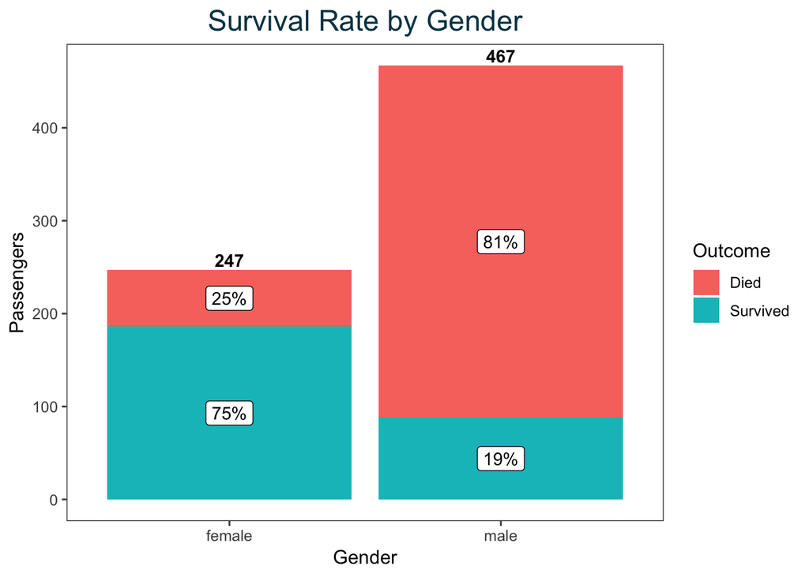

The above plot gives us enough statistic to what we have discussed above in one great summary.  
Hence, my initial assumption is correct for Titanic and gender is also a good feature for modelling since it has a really good split between died and survived.

## 3.2 Pclass

Pclass is passenger class containing of 3 factors : 1,2 and 3. Passengers in class 1 pay more fees than class 2 and 3. I also expect higher classes to have better access to life boats and less crowded than lower classes. Let’s anaylse the plot below to see if I can validate the above assumptions against training data.

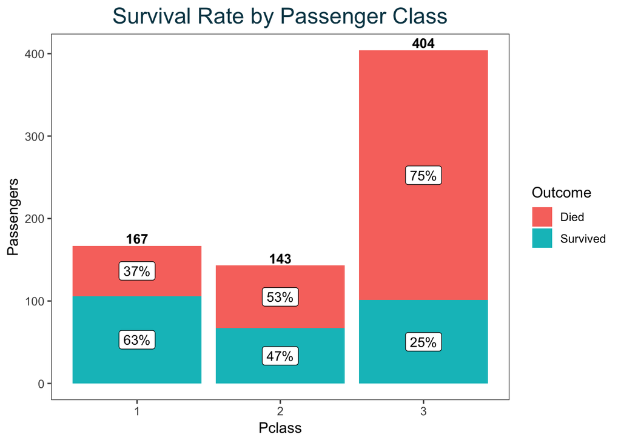

From the above plot, we can see the following :

- 63% of passengers in class 1 survived
- 47% of passengers in class 2 survived
- 25% of passengers in class 3 survived

It does validate my assumptions as we can see if you happened to be in Titanic at that time and bought a ticket in passenger class 3, then you were most likely not going to survive.

Again, this is another good feature which can be used in my model later on to predict test dataset.

## 3.3 Family

In Titanic dataset, there are two features that are quite similar :

- Parch - travelling with parents or children
- Sibsp - travelling with sibbling or spouses

I am not sure if there are any different between the two and I personally think they should be grouped as *FamilySize*. Logically, family members will try to help each other to survive the ordeal and probably have better chance since they work in a group.

I am going to create a new feature called *FamilySize* which is the sum of *Parch* and *SibSp*. I also added 1 in the end which is basically that person itself otherwise you just count your other family members excluding you.

```r
# group to determine family/single
train$FamilySize <- train$Parch + train$SibSp + 1

# work out the composition of the data
a <- prop.table(table(train$FamilySize)) * 100
b <- table(train$FamilySize)
rbind(Count = b,Pctg = round(a,1))
```

```
##           1     2    3    4   5    6 7   8 11
## Count 439.0 123.0 81.0 25.0 8.0 18.0 7 6.0  7
## Pctg   61.5  17.2 11.3  3.5 1.1  2.5 1 0.8  1
```

From the above table we can see the following observations :

- 61.5% travelling alone
- 17.2% travelling with another family
- 11.3% travelling with another 2 family members
- The remaining travelling with more than 2 family members

Which groups had better chance to survive in this disaster? I use prop and table function again to show this.

```r
num <- table(train$FamilySize,train$Survived)
pct <- round(prop.table(table(train$FamilySize,train$Survived),1),3)*100
tbl <- cbind(num,pct)
colnames(tbl) <- c('Died','Survived','Died %','Survived %')
tbl
```

```
##    Died Survived Died % Survived %
## 1   306      133   69.7       30.3
## 2    56       67   45.5       54.5
## 3    32       49   39.5       60.5
## 4     8       17   32.0       68.0
## 5     6        2   75.0       25.0
## 6    15        3   83.3       16.7
## 7     4        3   57.1       42.9
## 8     6        0  100.0        0.0
## 11    7        0  100.0        0.0
```

The table above show the split in terms of actual numbers on the left and percentages on the right. From there we can draw the following summary :

- Those passengers travelling in category 1,5,6 and 7 had between 16.7% to 42.9% chance to survive
- Those passengers with 2-3 family members had ~55% chance to survive
- Those passengers with 4 family members had 68% chance to survive
- Passengers travelling with 8 or more family members had 100% chance to die

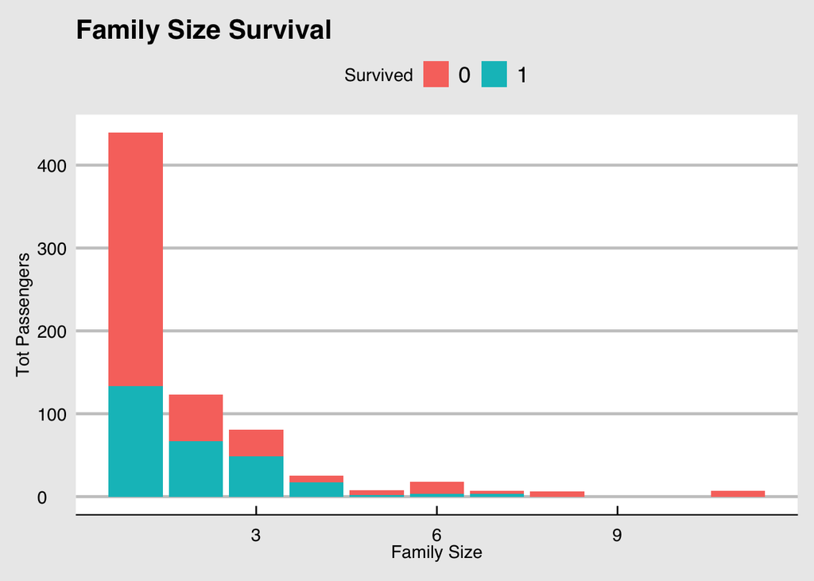

```r
ggplot(data = train, aes(x=FamilySize)) + geom_bar(aes(fill=Survived)) + labs(x='Family Size', y='Tot Passengers', title='Family Size Survival') + theme_economist_white()
```

When I plot the above statistic, we can see there were not that many families with 4 or more members. Those families who all died as per our train table probably only a small proportion of the whole dataset. Let’s find out which families they were.

```r
train %>% filter(FamilySize>7) %>% select(Name,Sex,Age, FamilySize, Pclass) %>% arrange(Name)
```

| Name | Sex | Age | FamilySize | Pclass |
| --- | --- | --- | --- | --- |
| Goodwin, Master. Harold Victor | male | 9.00000 | 8 | 3 |
| Goodwin, Master. Sidney Leonard | male | 1.00000 | 8 | 3 |
| Goodwin, Master. William Frederick | male | 11.00000 | 8 | 3 |
| Goodwin, Miss. Lillian Amy | female | 16.00000 | 8 | 3 |
| Goodwin, Mr. Charles Edward | male | 14.00000 | 8 | 3 |
| Goodwin, Mrs. Frederick (Augusta Tyler) | female | 43.00000 | 8 | 3 |
| Sage, Master. Thomas Henry | male | 29.69912 | 11 | 3 |
| Sage, Miss. Constance Gladys | female | 29.69912 | 11 | 3 |
| Sage, Miss. Dorothy Edith "Dolly" | female | 29.69912 | 11 | 3 |
| Sage, Miss. Stella Anna | female | 29.69912 | 11 | 3 |

[output cut: 3 more lines]

We found out from the results above, the two families were *The Goodwin and The Sage*. It also probably tells another story that bigger families struggled to get everyone on lifeboats and they probably sticked around to each other if they did not make it. Especially these two families were also in passenger class 3 and we know most people died in this class because of poor life support due to lower fares.

## 3.4 Embarked

```r
TotalPassenger <- table(train$Embarked)
Pctg <- round(prop.table(table(train$Embarked)),3)*100
Pctg <- Pctg[-1]
TotalPassenger <- TotalPassenger[-1]
rbind(TotalPassenger,Pctg)
```

```
##                    C    Q     S
## TotalPassenger 141.0 61.0 512.0
## Pctg            19.7  8.5  71.7
```

There were three embarkation points for Titanic :

- C - Cherbourg in France
- Q - Queenstown in Ireland
- S - Southampton in England

You can see from table, most people embarked from Southampton followed by Cherbourg and Queenstown. I asked myself a question regarding this feature. Would it be logical to determine if someone survived based on his/her embarkation point? It does not seem logical and probably related more to other features such as which passenger class they were in.

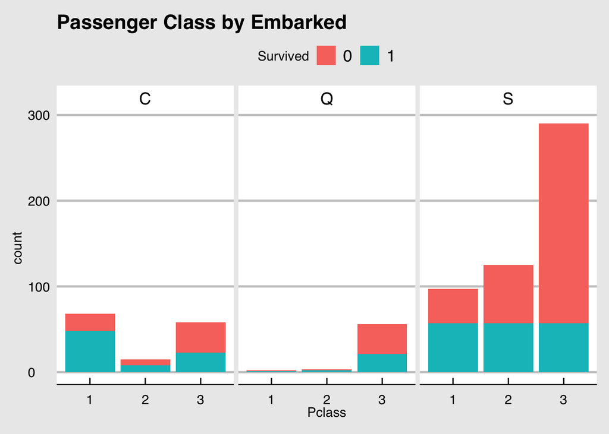

```r
train %>% ggplot(aes(x=Pclass, fill=Survived)) + geom_bar() + facet_wrap(~Embarked) + theme_economist_white() + labs(title="Passenger Class by Embarked")
```

Using facet wrap in ggplot, we can see significant numbers of passengers from Southampton were in passenger class 3. Is it fair to say you would not survived because you were from Southampton? Probably not, it is probably fairer to say you had significant lower income from Southampton travelling in passenger class 3.

You can also see that most people embarking from Cherbourg mostly survived because most of them sit in class 1 while most people from Southampton sat in class 3. As a result of this, this feature is not really usefull for modelling since this is already captured in passenger class.

# 3.5 Age

The next feature I want to analyse a bit further is Age and need to figure out how to group the age to help machine learning use it as another categorical feature.

There are two points that I want to analyse further :

1. Did a lot of kids survive?
2. How about the older people like over 60?

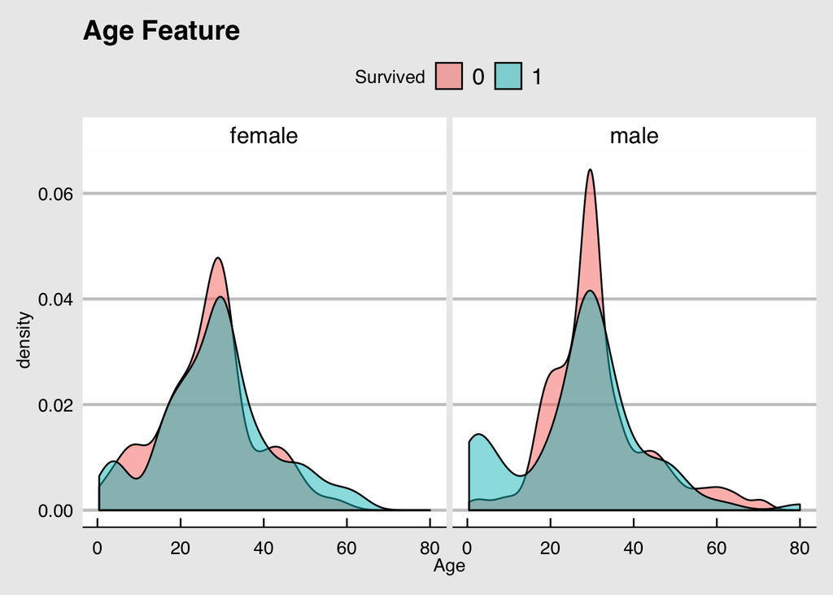

```r
p <- train %>%
  ggplot(aes(x = Age, fill=Survived))

p + geom_density(alpha=0.5) + facet_wrap(~Sex) + labs(title="Age Feature") + theme_economist_white()
```

The above density plots give me the answers to my previuos questions

- More male under 15 survived
- More male over 60 died
- Strange pattern in female under 15 requires further investigation

Let’s drill down the strange pattern for female under 15 using below code.

```r
tmp <- train %>% filter(Age<15 & Sex=='female')
table(tmp$FamilySize,tmp$Survived)
```

```
##
##     0 1
##   1 1 2
##   2 0 5
##   3 1 8
##   4 1 5
##   5 2 0
##   6 2 0
##   7 2 1
```

```r
tmp %>% filter(FamilySize>4) %>% arrange(Name)
```

| PassengerId | Survived | Pclass | Name | Sex | Age | SibSp | Parch | Ticket | Fare | Cabin | Embarked | FamilySize |
| --- | --- | --- | --- | --- | --- | --- | --- | --- | --- | --- | --- | --- |
| 814 | 0 | 3 | Andersson, Miss. Ebba Iris Alfrida | female | 6 | 4 | 2 | 347082 | 31.2750 |  | S | 7 |
| 542 | 0 | 3 | Andersson, Miss. Ingeborg Constanzia | female | 9 | 4 | 2 | 347082 | 31.2750 |  | S | 7 |
| 234 | 1 | 3 | Asplund, Miss. Lillian Gertrud | female | 5 | 4 | 2 | 347077 | 31.3875 |  | S | 7 |
| 148 | 0 | 3 | Ford, Miss. Robina Maggie "Ruby" | female | 9 | 2 | 2 | W./C. 6608 | 34.3750 |  | S | 5 |
| 25 | 0 | 3 | Palsson, Miss. Torborg Danira | female | 8 | 3 | 1 | 349909 | 21.0750 |  | S | 5 |
| 635 | 0 | 3 | Skoog, Miss. Mabel | female | 9 | 3 | 2 | 347088 | 27.9000 |  | S | 6 |
| 643 | 0 | 3 | Skoog, Miss. Margit Elizabeth | female | 2 | 3 | 2 | 347088 | 27.9000 |  | S | 6 |

Based on the data above, I could reveal the reason why they were a lot of female kids died. They were part of some big families already mentioned previouly where most of the family members died. These kids were part of Andersson, Asplund, Palsson and Skoog where they were families with more than 4 people. Unfortunately, these families were also in passenger class 3 which did not help with their chances to survive due to poor facilities etc.

I will create another categorical feature for Age and call it AgeGrp with three categories :

1. Kids
2. Adults
3. Seniors

```r
train$AgeGrp[train$Age<=15] <- 'Kids'
train$AgeGrp[train$Age>15 & train$Age<=59] <- 'Adults'
train$AgeGrp[train$Age>59] <- 'Seniors'
train$AgeGrp <- factor(train$AgeGrp)
```

```r
a <- table(train$AgeGrp)
b <- prop.table(table(train$AgeGrp)) * 100
rbind(Count=a,Pctg=round(b,1))
```

```
##       Adults Kids Seniors
## Count    628 65.0    21.0
## Pctg      88  9.1     2.9
```

The above is the new category for age group and we can see there were not many people seniors (above 59), only 2.9% of the sample size. But there were 65 kids (under 15) on board, roughly about 9.1% of total passengers in training dataset.

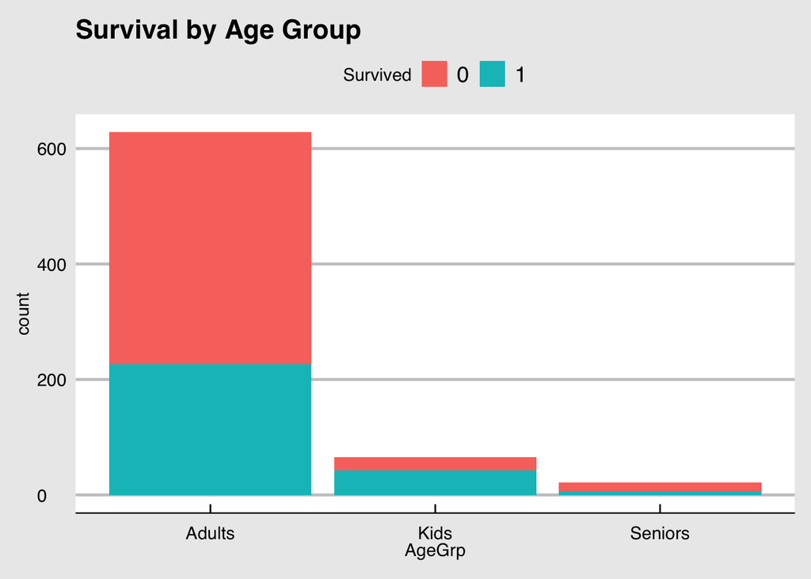

```r
train %>% ggplot(aes(x=AgeGrp, fill=Survived)) + geom_bar() + theme_economist_white() + labs(title="Survival by Age Group")
```

Based on this new grouping, I’m quite satisfied it can help predicting the outcome of test dataset later on.

# 3.6 Fare

Fare is closely related to passenger class as we expect passengers in class 1 to have higher fees than class 3. Let’s review this using box plot below.

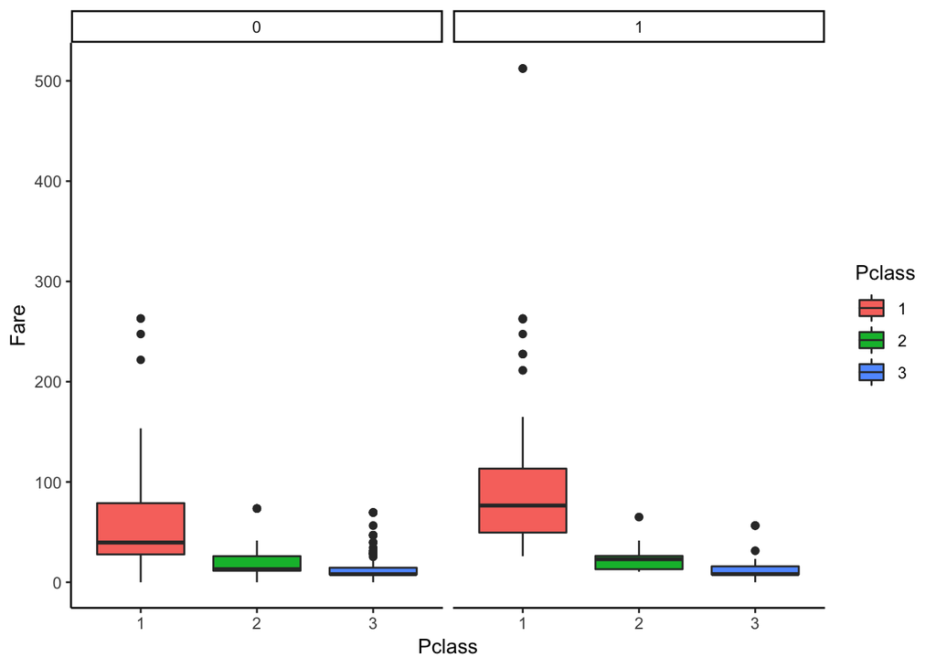

```r
train %>% ggplot(aes(x = Pclass, y = Fare, fill=Pclass)) + geom_boxplot() + facet_grid(~Survived) + theme_classic()
```

After adding facet grid to split by survived factor, I notice there are some outliers in passenger class 3 that warrant further investigation. It seems to me there were passengers paying a bit more in class 3, probably because of last minutes booking or something else.

The summary of passenger class 3 below showing 3rd quantile around 15.5 whilst the max value is 69.55. There is a huge gap caused by these outliers.

```r
s <- train %>% filter(Pclass==3) %>% .$Fare
summary(s)
```

```
##    Min. 1st Qu.  Median    Mean 3rd Qu.    Max.
##    0.00    7.75    8.05   13.53   15.31   69.55
```

I decided to find out a bit more on fare greater than 15.50 and group them by family size to see if I can find another interesting story from the data. I googled some of these families from the table below to find out a bit more information. Some of these fares included rail fares because New York was not their final destination. A lot of these families were plannning to migrate to United States going to various states or even Canada to start a better life. A lof of them came from other countries outside England as well and embarked from Southampton.

For example, the whole Anderson family perished with Titanic and they came from Sweden on the way to Canada. It’s quite amazing I can find out all these names from dataset and google them to find out more stories about them. Now I know the reason of the outliers, I’m going to include this feature in my modelling as it is.

```r
train %>% filter(Pclass==3 & Fare>15.50) %>% select(Name, FamilySize, Age, Embarked) %>% arrange(desc(FamilySize,Name))
```

| Name | FamilySize | Age | Embarked |
| --- | --- | --- | --- |
| Sage, Master. Thomas Henry | 11 | 29.69912 | S |
| Sage, Miss. Constance Gladys | 11 | 29.69912 | S |
| Sage, Mr. Frederick | 11 | 29.69912 | S |
| Sage, Mr. George John Jr | 11 | 29.69912 | S |
| Sage, Miss. Stella Anna | 11 | 29.69912 | S |
| Sage, Mr. Douglas Bullen | 11 | 29.69912 | S |
| Sage, Miss. Dorothy Edith "Dolly" | 11 | 29.69912 | S |
| Goodwin, Master. William Frederick | 8 | 11.00000 | S |
| Goodwin, Miss. Lillian Amy | 8 | 16.00000 | S |
| Goodwin, Master. Sidney Leonard | 8 | 1.00000 | S |

[output cut: 84 more lines]

# 4. Machine Learning

After analysing all the features in Titanic dataset, I have finally come up with 5 final features :

- Pclass
- AgeGrp
- FamilySize
- Fare
- Sex

In the next section, I will be running a few algorithms using *Caret* to decide which one to choose.

# 4.1 Finding the best model

The good thing about Caret, you can try multiple algorithms already included in this package. In here, I will try to apply some of the most popular algorithms below to decide which one I am going to use

- Decision Tree
- Random Forest
- XgBoost
- KNN
- Support Vector Machine
- GLM

```r
# create 10 fold validation
control <- trainControl(method="cv", number=10)
metric <- "Accuracy"

set.seed(7)

fit.rf <- train(Survived ~ Sex + Pclass + AgeGrp + FamilySize + Fare, data=train, method="rf", metric=metric, trControl=control)
fit.rpart <- train(Survived ~ Sex + Pclass + AgeGrp + FamilySize + Fare, data=train, method="rpart", metric=metric, trControl=control)
fit.glm <- train(Survived ~ Sex + Pclass + AgeGrp + FamilySize + Fare, data=train, method="glm", metric=metric, trControl=control)
fit.knn <- train(Survived ~ Sex + Pclass + AgeGrp + FamilySize + Fare, data=train, method="knn", metric=metric, trControl=control)
fit.xgbTree <- train(Survived ~ Sex + Pclass + AgeGrp + FamilySize + Fare, data=train, method="xgbTree", metric=metric, trControl=control)
fit.SVM <- train(Survived ~ Sex + Pclass + AgeGrp + FamilySize + Fare, data=train, method="svmRadial", metric=metric,trControl=control)
```

```r
# summarize accuracy of models
results <- resamples(list(DecisionTree=fit.rpart,RandomForest=fit.rf,XgBoost=fit.xgbTree,  KNN=fit.knn, SupportVector=fit.SVM, GLM=fit.glm))
summary(results)
```

```
##
## Call:
## summary.resamples(object = results)
##
## Models: DecisionTree, RandomForest, XgBoost, KNN, SupportVector, GLM
## Number of resamples: 10
##
## Accuracy
##                    Min.   1st Qu.    Median      Mean   3rd Qu.      Max.
## DecisionTree  0.7605634 0.8035016 0.8239437 0.8150626 0.8333333 0.8450704
## RandomForest  0.7746479 0.8175372 0.8472222 0.8375000 0.8606221 0.8873239
## XgBoost       0.6901408 0.7665786 0.8055556 0.8025235 0.8421362 0.9014085
## KNN           0.7361111 0.7473592 0.7887324 0.7816706 0.8000293 0.8450704
## SupportVector 0.7746479 0.7944542 0.8169014 0.8207355 0.8526995 0.8750000
## GLM           0.7746479 0.7887324 0.8112285 0.8123435 0.8298611 0.8732394
##               NA's
## DecisionTree     0
## RandomForest     0
## XgBoost          0
## KNN              0
## SupportVector    0
## GLM              0
##
## Kappa
##                    Min.   1st Qu.    Median      Mean   3rd Qu.      Max.
## DecisionTree  0.4808602 0.5642869 0.6142254 0.5967392 0.6412649 0.6736314
## RandomForest  0.5286307 0.6041037 0.6677254 0.6475591 0.6911558 0.7609428
## XgBoost       0.3131047 0.5213086 0.5847803 0.5772976 0.6568483 0.7862366
## KNN           0.4483871 0.4641255 0.5476919 0.5411085 0.5831798 0.6736314
## SupportVector 0.5218855 0.5570661 0.6058716 0.6152602 0.6816184 0.7317881
## GLM           0.5218855 0.5332354 0.5766442 0.5904884 0.6277273 0.7367120
##               NA's
## DecisionTree     0
## RandomForest     0
## XgBoost          0
## KNN              0
## SupportVector    0
## GLM              0
```

If you look at the results from Accuracy table, you can see Random Forest has the highest mean ouf of the other models.

We can probably plot the results to make it easier to visualise and see the best performing models for this exercise.

As a result of this, I have decided to use **Random Forest** as my model to predict the outcome.

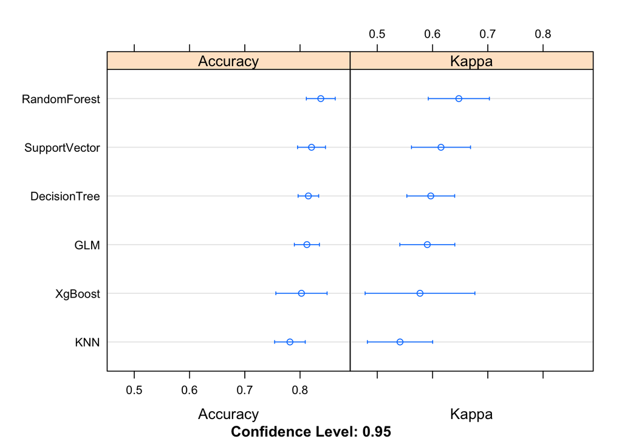

```r
dotplot(results)
```

# 4.1 Random Forest with default setting

Using the default setting in Caret for Random Forest, we can see the details of the best model. The default parameter is mtry using values of 2,4 and 7. Mtry is basically random predictors chosen by the model when building various different trees. It is very interesting to see the best accuracy was achieved using 2 mtry (2 predictors) only.

I can probably fine tune this since I have 5 features as my predictors so this can be changed instead of using default values.

```r
print(fit.rf)
```

```
## Random Forest
##
## 714 samples
##   5 predictor
##   2 classes: '0', '1'
##
## No pre-processing
## Resampling: Cross-Validated (10 fold)
## Summary of sample sizes: 642, 642, 642, 643, 642, 643, ...
## Resampling results across tuning parameters:
##
##   mtry  Accuracy   Kappa
##   2     0.8375000  0.6475591
##   4     0.8277778  0.6305279
##   7     0.8207355  0.6198347
##
## Accuracy was used to select the optimal model using the largest value.
## The final value used for the model was mtry = 2.
```

The plot below shows the three default values in Random Forest and 2 predictos give the maximum accuracy around 83.7%.

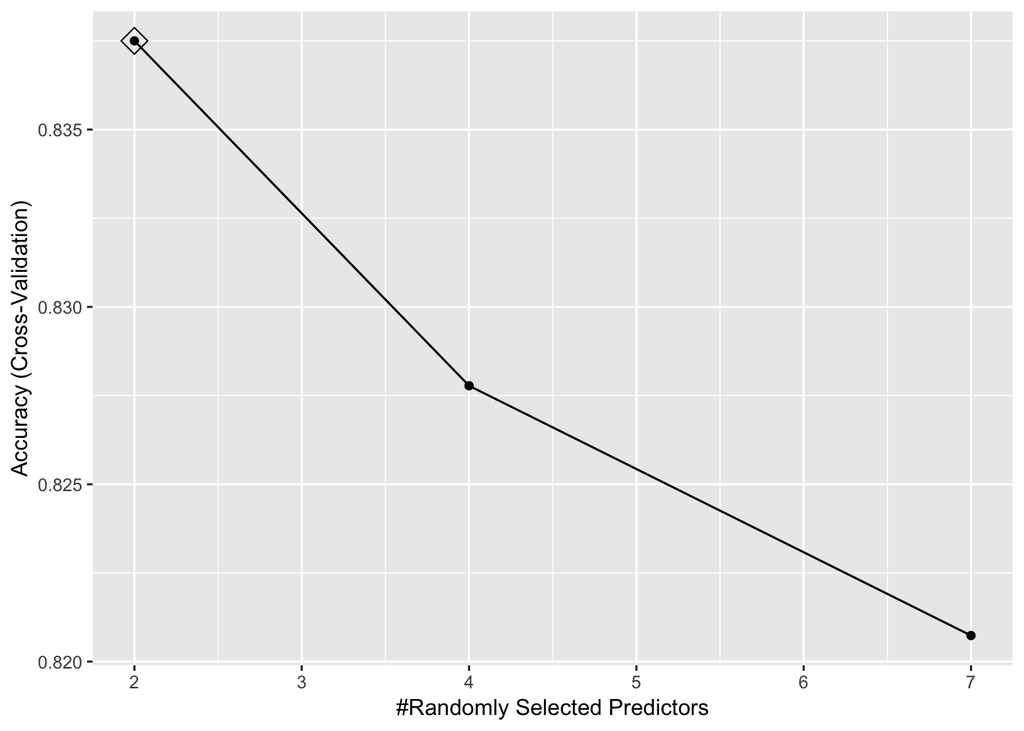

```r
ggplot(fit.rf, highlight = TRUE)
```

Another function in caret called final model will show the error rate of 15.83%. This is basically related to our accurarcy of ~84% and hence the error rate is the residual around 16%.

```r
fit.rf$finalModel
```

```
##
## Call:
##  randomForest(x = x, y = y, mtry = param$mtry)
##                Type of random forest: classification
##                      Number of trees: 500
## No. of variables tried at each split: 2
##
##         OOB estimate of  error rate: 15.83%
## Confusion matrix:
##     0   1 class.error
## 0 405  35  0.07954545
## 1  78 196  0.28467153
```

# 4.2 Fine tuning Random Forest

```r
seq(2,5,1)
```

```
## [1] 2 3 4 5
```

```r
# Machine learning one using 7 fold validation
library(caret)
train$Survived <- factor(train$Survived)
set.seed(7)

# create 7 fold validation
control <- trainControl(method="repeatedcv", number=7, repeats=3)
metric <- "Accuracy"

# Random Forest
fit.rf_final <- train(Survived ~  Sex + Pclass + AgeGrp + FamilySize + Fare, data=train, metric=metric, method="rf", tuneGrid = data.frame(mtry = seq(2, 5, 1)), trControl=control)

# print model
print(fit.rf_final)
```

```
## Random Forest
##
## 714 samples
##   5 predictor
##   2 classes: '0', '1'
##
## No pre-processing
## Resampling: Cross-Validated (7 fold, repeated 3 times)
## Summary of sample sizes: 612, 612, 612, 613, 612, 612, ...
## Resampling results across tuning parameters:
##
##   mtry  Accuracy   Kappa
##   2     0.8375306  0.6471850
##   3     0.8388946  0.6502177
##   4     0.8351916  0.6450446
##   5     0.8352192  0.6471899
##
## Accuracy was used to select the optimal model using the largest value.
## The final value used for the model was mtry = 3.
```

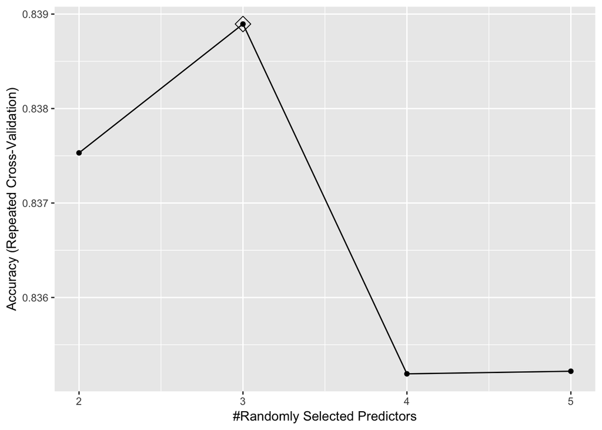

```r
ggplot(fit.rf_final, highlight = TRUE)
```

```r
fit.rf$finalModel
```

```
##
## Call:
##  randomForest(x = x, y = y, mtry = param$mtry)
##                Type of random forest: classification
##                      Number of trees: 500
## No. of variables tried at each split: 2
##
##         OOB estimate of  error rate: 15.83%
## Confusion matrix:
##     0   1 class.error
## 0 405  35  0.07954545
## 1  78 196  0.28467153
```

As you can see from the above results, my accuracy improved to 83.9% and mtry changed from 2 to 3. I am going to compare the results against the train data to validate the accuracy. The prediction is added to a new field called Survived2. The accuracy is around 87% with balanced accuracy around 85% so this is a good result. I am not expecting the model to predict the outcome 100% since there were a lot of factors not captured in the dataset and I think to get around 80% accuracy is pretty good result already.

```r
train$Survived2 <- predict(fit.rf_final,train)
train$Survived2 <- factor(train$Survived2)
confusionMatrix(train$Survived2,train$Survived)
```

```
## Confusion Matrix and Statistics
##
##           Reference
## Prediction   0   1
##          0 416  68
##          1  24 206
##
##                Accuracy : 0.8711
##                  95% CI : (0.8443, 0.8948)
##     No Information Rate : 0.6162
##     P-Value [Acc > NIR] : < 2.2e-16
##
##                   Kappa : 0.7191
##  Mcnemar's Test P-Value : 7.358e-06
##
##             Sensitivity : 0.9455
##             Specificity : 0.7518
##          Pos Pred Value : 0.8595
##          Neg Pred Value : 0.8957
##              Prevalence : 0.6162
##          Detection Rate : 0.5826
##    Detection Prevalence : 0.6779
##       Balanced Accuracy : 0.8486
##
##        'Positive' Class : 0
##
```

## 4.3 Predicting the test dataset

I am going to apply my prediction againt the test dataset which the model has not seen. But first, I am going to fix some of the features such as family size and age group in test dataset.

```r
test$FamilySize <- test$Parch + test$SibSp + 1


test$AgeGrp[test$Age<=15] <- 'Kids'
test$AgeGrp[test$Age>15 & test$Age<=59] <- 'Adults'
test$AgeGrp[test$Age>59] <- 'Seniors'
test$AgeGrp <- factor(test$AgeGrp)
```

The final out come against test dataset showing accuracy of 81.3% with balanced accuracy about 78% so it is quite balanced in predicting 0 and 1.

```r
test$Survived2 <- predict(fit.rf_final,test)
test$Survived2 <- factor(test$Survived2)
confusionMatrix(test$Survived2,test$Survived)
```

```
## Confusion Matrix and Statistics
##
##           Reference
## Prediction  0  1
##          0 98 22
##          1 11 46
##
##                Accuracy : 0.8136
##                  95% CI : (0.7483, 0.8681)
##     No Information Rate : 0.6158
##     P-Value [Acc > NIR] : 1.058e-08
##
##                   Kappa : 0.5936
##  Mcnemar's Test P-Value : 0.08172
##
##             Sensitivity : 0.8991
##             Specificity : 0.6765
##          Pos Pred Value : 0.8167
##          Neg Pred Value : 0.8070
##              Prevalence : 0.6158
##          Detection Rate : 0.5537
##    Detection Prevalence : 0.6780
##       Balanced Accuracy : 0.7878
##
##        'Positive' Class : 0
##
```